# Ликбез по производной, градиент и метод градиентного спуска

Зарманбетов Ахмед

```r
library(ggplot2)
library(tibble)
library(dplyr)
```

### Функция и ее производная

Вспомним, что **функция** – это отображение одного множества в другое, но так, что каждому элементу одного множества соответствует один и только один элемент из другого множества. Записывается это так: $f: \mathbb{R}^n \rightarrow \mathbb{R}$.

Вспомним простую функцию $y = x^2$. Давайте нарисуем её!

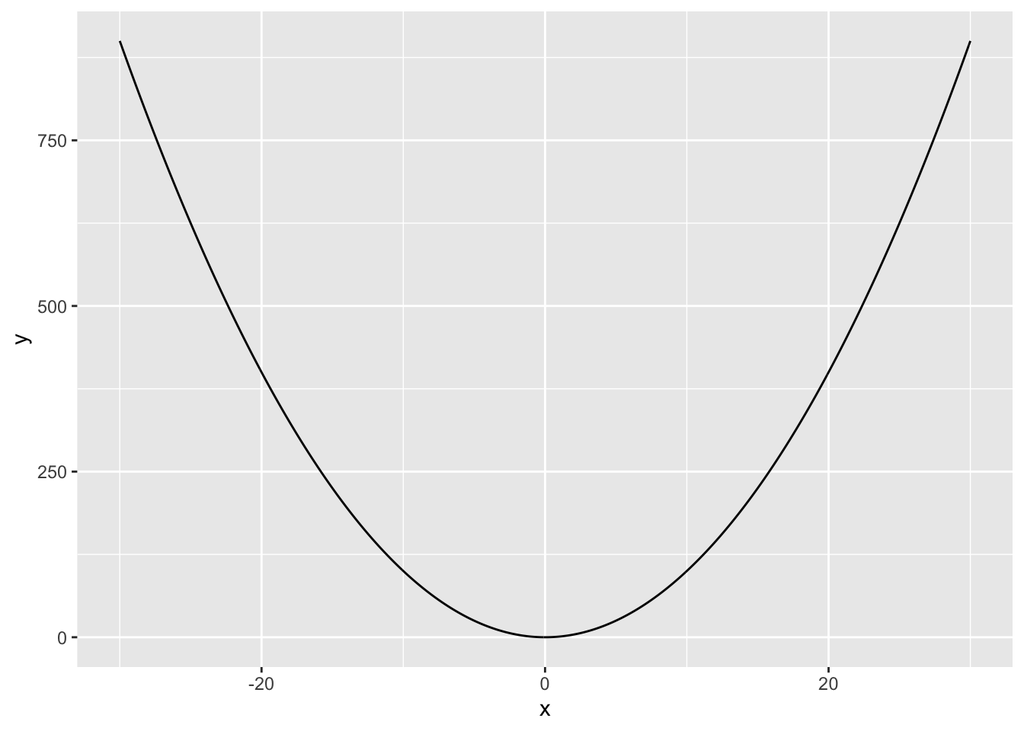

```r
square <- function(x){
  return(x^2)
}

df <- tibble(x = seq(-30, 30, by = 0.1),
             y = square(x))

ggplot(df, aes(x, y)) +
  geom_line()
```

В данном случае $y$ – это функция от одной переменной $x$. На таком графике мы можем явно увидеть зависимость функции от ее аргумента. Видим, что минимум находится в точке $x = 0$. Чуть позже мы будем работать с функциями нескольких переменных.

Теперь вспомним что такое производная. Не будем лезть в тяжелую математику. Нам будет важно следующее определение. **Производная** – скорость изменения функции в данной точке.

Вспомним некоторые производные:

1. $c' = 0, c = const$
2. $(x^n)' = nx^{n-1}$
3. $(e^x)' = e^x$
4. $(\ln{x})' = \frac{1}{x}$
5. $(\sin{x})' = \cos{x}$
6. $(\cos{x})' = -\sin{x}$

А также некоторые свойства:

1. $(cf(x))' = cf'(x)$ – константу можно вынести из под знака производной
2. $(f(x) + g(x))' = f'(x) + g'(x)$ – производная суммы это сумма производных
3. $[f(g(x))]' = f'(g(x))g'(x)$ – производная сложной функции

А теперь порешаем некоторые примеры, чтобы лучше с этим разобраться.

1. $y = 100$
2. $y = x^2$
3. $y = 5x$
4. $y = 10x^3$
5. $y = 4x + cos(x)$
6. $y = \ln(x^2)$
7. $y = (10 - 5x)^2$

Давайте возьмем функцию $y = x^2$. Представим, что мы находимся в точке $x_0 = 5$. Значение функции в этой точке равно 25.

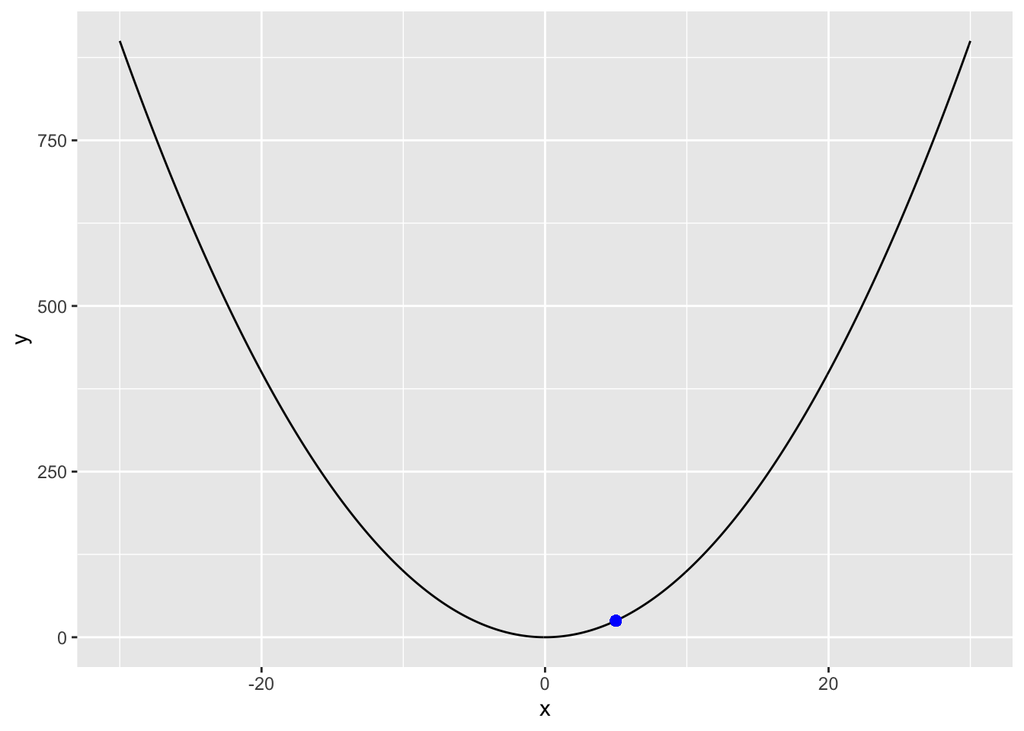

```r
x0 <- 5
ggplot(df, aes(x, y)) +
  geom_line() +
  geom_point(x = x0, y = square(x0), color = 'blue', size = 2)
```

Производная этой функции: $y' = 2x$. . Давайте найдем ее производную в этой точке.

```r
der_square <- function(x){
  return(2*x)
}

der_square(x0)
```

```
## [1] 10
```

Производная в этой точке равна 10. Важное свойство производной состоит в том, что если производная положительна, то чтобы увеличить значение функции надо увеличивать значение аргумента. Аналогично, если мы хотим уменьшить значение функции, мы должны уменьшить аргумент. Если значение производной в точке отрицательно, то все ровно наоборот.

Объединяя эти два случая получаем:

$x_0 = x_0 + sign(f'(x_0)) t$

Второй вопрос, а на сколько нужно увлечивать или уменьшать?

### Минимум функции от одного аргумента

В школе нас учили находить минимум или максимум функции. Нужно было найти первую производную, приравнять ее к нулю и дело почти в шляпе. Оставалось только решить уравнение и проверить точки на минимум и максимум или найти вторую производную и понять по ней. Мы отойдем от этого подхода и будем искать минимум немного по-другому. Позже мы поймем почему мы отошли от стандартного метода.

### Метод градиентного спуска (GD)

Изучим метод градиентного спуска. Его смысл заключается в том, чтобы итеративно искать минимум функции. Давайте вернемся к функции $y = x^2$. Изначально мы не знаем в какой точке находится минимум этой функции. Давайте выберем рандомно какое-то число. Пусть это будет $x_0 = 10$. Если мы найдем производную функции в этой точке, то поймем в какую сторону нам нужно двигаться, чтобы увеличить значение функции. Мы пойдем в обратную сторону, так как мы хотим минимизировать нашу функцию. Поэтому изменим значение нашего аргумента $x_0$ на величину производной. Только эта величина может принимать достаточно большие значения, поэтому давайте умножим ее на константу $\alpha$, которую мы будем задавать сами. Эта константа называется скорость обучения.

$$x_0 = x_0 - \alpha \frac{df(x)}{dx} \bigg|_{x=x_0}$$

После того как мы сделали одну итерацию мы проделали шаг градиентного спуска. Будем продолжать его делать, пока функция не начнет уменьшаться на очень маленькую величину. Давайте попробуем проделать это в коде и визуализировать.

```r
alpha <- 0.1
x0 <- 10

for(i in 1:20){
  p <- ggplot(df, aes(x, y)) +
        geom_line() +
        geom_point(x = x0, y = square(x0), color = 'blue', size = 2)
  print(p)
  x0 <- x0 - alpha * der_square(x0)
  readline('Enter:')
}
```

[output not shown]

Скорость обучения это важная штука. Давайте попробуем ее уменьшить.

```r
alpha <- 0.01
x0 <- 10

for(i in 1:20){
  p <- ggplot(df, aes(x, y)) +
        geom_line() +
        geom_point(x = x0, y = square(x0), color = 'blue', size = 2)
  print(p)
  x0 <- x0 - alpha * der_square(x0)
  readline('Enter:')
}
```

[output not shown]

Видно, что сходимость стала заметно медленее. А теперь давайте попробуем увеличить скорость обучения.

```r
alpha <- 1.2
x0 <- 10

for(i in 1:5){
  p <- ggplot(df, aes(x, y)) +
        geom_line() +
        geom_point(aes(x = x0, y = square(x0)), color = 'blue', size = 2)
  print(p)
  x0 <- x0 - alpha * der_square(x0)
  readline('Enter:')
}
```

[output not shown]

Случилось ужасное. Мы перескакиваем наш минимум и алгорим начинает расходится. Со скоростью обучения надо быть аккуратнее.

Давайте возьмем функцию поинтересней.

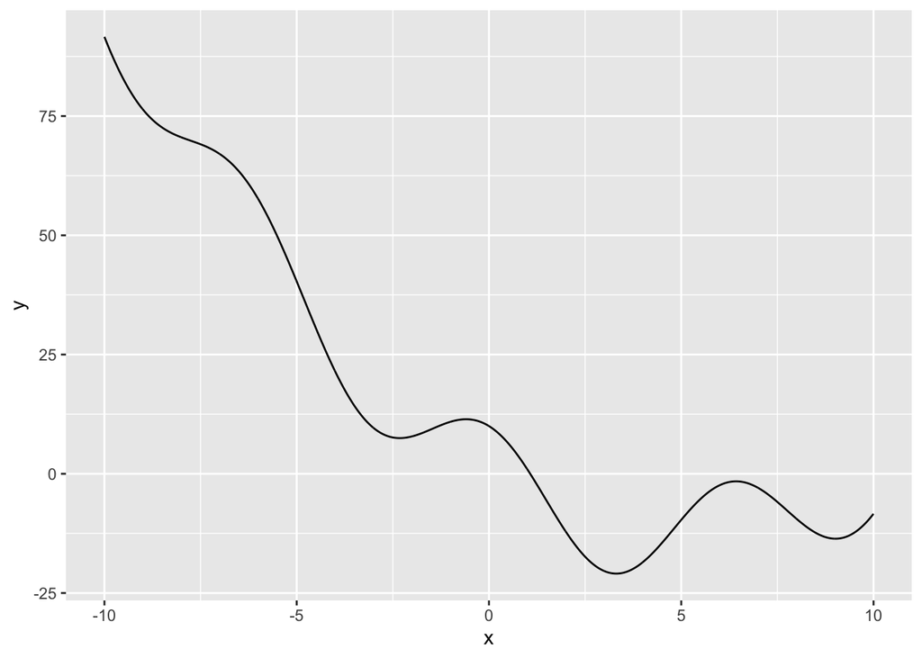

```r
our_function <- function(x){
  y <- 10 * cos(x) + 0.5*x^2 -5*x
  return(y)
}

df <- tibble(x = seq(-10,10, by = 0.01),
             y = our_function(x))

ggplot(df, aes(x, y)) +
  geom_line()
```

Вот такая интересная функция. Найдем ее производную.

```r
der_our_function <- function(x){
  y <- -10*sin(x) + x - 5
  return(y)
}
```

Попробуем найти минимум с помощью GD.

```r
x0 <- -10
alpha <- 0.01
for(i in 1:100){
  p <- ggplot(df, aes(x, y)) +
    geom_line() +
    geom_point(x = x0 , y = our_function(x0), color='red')
  # print(p)
  x0 <- x0 - alpha * der_our_function(x0)
  # readline('Enter:')
}
print(p)
```

[output not shown]

$$\nu_t = \alpha \nu_{t-1} + \eta \frac{df(x)}{dx} \bigg|_{x=x_0}$$
$$x_t = x_{t-1} - \nu_t$$

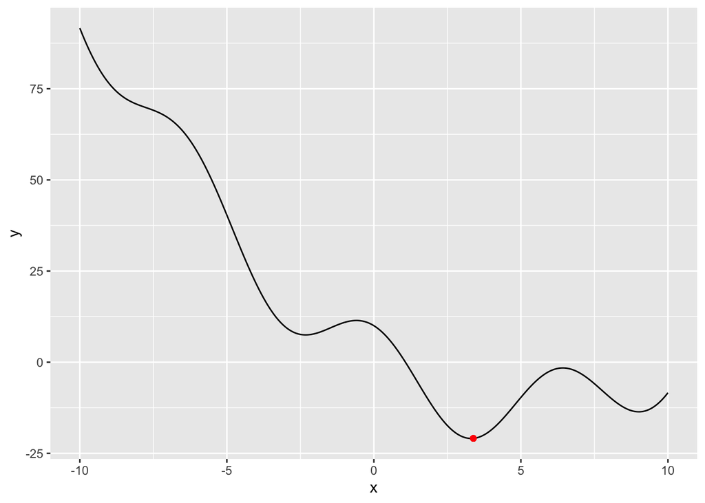

```r
x0 <- -10
eta <-  0.05
alpha <-  0.7
nu <- 0

for(i in 1:30){
  p <- ggplot(df, aes(x, y)) +
    geom_line() +
    geom_point(x = x0 , y = our_function(x0), color='red')
  # print(p)
  nu <-  alpha * nu + eta * der_our_function(x0)
  x0 <-  x0 - nu
  # readline('Enter:')
}
print(p)
```